# Simulating communities with mobsim

Felix May

2017-11-02

# 1 Biodiversity components

Biodiversity in any sampling area depends on three components:

1. The total number of individuals (total abundance)
2. The relative abundances of species
3. The spatial distribution of species

`mobsim` provides functions to simulate communities and thereby control for all these components. This vignette first shows how to simulate non-spatial species abundance distributions (SADs) and second, how to simulate spatially- explicit community data with `mobsim`.

# 2 Simulating species abundance distributions

For this purpose `mobsim` provides the function `sim_sad`, which is a wrapper around the function `rsad` from the package sads. In contrast to `rsad`, `sim_sad` allows simulating communities with user-defined number of species *and* user-defined total number of individuals.

Here is an example for the simulation of an SAD using a log-normal model.

```r
library(mobsim)

abund1 <- sim_sad(s_pool = 100, n_sim = 1000, sad_type = "lnorm",
                  sad_coef = list("meanlog" = 5, "sdlog" = 0.5))
head(abund1)
```

```
## species1 species2 species3 species4 species5 species6
##       30       25       23       23       22       22
```

```r
summary(abund1)
```

```
## Species abundance distribution
##
## No. of individuals:  1000
## No. of species:  100
##
## Min. abundance:  1
## Mean abundance:  10
## Max. abundance:  30
```

`sim_sad` first simulates a *relative* species abundance distribution according to the chosen SAD model and then samples the requested number of individuals according to this relative abundance distribution. Because of the use of a relative abundance distribution as intermediate step, in the log-normal model the mean abundance is defined by the simulated number of individuals (`n_sim`) divided by the number of species (`s_pool`). Therefore, for the log-normal model `sim_sad` offers also a simpler parameterization that just specifies the coefficient of variation (`cv_abund`) of the log-normal SAD.

```r
abund2 <- sim_sad(s_pool = 100, n_sim = 1000, sad_type = "lnorm",
                  sad_coef = list("cv_abund" = 2))
summary(abund2)
```

```
## Species abundance distribution
##
## No. of individuals:  1000
## No. of species:  85
##
## Min. abundance:  1
## Mean abundance:  11.76471
## Max. abundance:  50
```

Obviously, the simulated community includes less species than the user-defined value of `s_pool = 100`. This is a consequence of the stochastic sampling from the relative abundance distribution. When some species have very low relative abundances, they might not be sampled into the simulated community. However, `sim_sad` offers the option `fix_s_sim = TRUE`, which results in the user-defined value of species in the simulation. This is implemented by adding very rare species to the community, while removing individuals from the common species. Please note that the constraint `fix_s_sim = TRUE` might result in deviations from the underlying theoretical SAD model.

```r
abund2a <- sim_sad(s_pool = 100, n_sim = 1000, sad_type = "lnorm",
                  sad_coef = list("cv_abund" = 2), fix_s_sim = T)
summary(abund2a)
```

```
## Species abundance distribution
##
## No. of individuals:  1000
## No. of species:  100
##
## Min. abundance:  1
## Mean abundance:  10
## Max. abundance:  118
```

The function `sim_sad` inherits all SAD models provided by `sads::rsad`. For a complete list see `?sim_sad`. Here, we show an example of how to simulate a log-series SAD. It has to be noted that for some SAD models the species richness is not a direct parameter, but emerges from the other parameters. This is also true for the log-series model. Therefore, the parameter `s_pool` is set to `NULL`.

```r
abund3 <- sim_sad(s_pool = NULL, n_sim = 10000, sad_type = "ls",
                  sad_coef = list("N" = 1e5, "alpha" = 20))
head(abund3)
```

```
## species1 species2 species3 species4 species5 species6
##      772      640      565      526      502      455
```

Of course the simulated number of species can be easily evaluated

```r
length(abund3)
```

```
## [1] 117
```

```r
summary(abund3)
```

```
## Species abundance distribution
##
## No. of individuals:  10000
## No. of species:  117
##
## Min. abundance:  1
## Mean abundance:  85.47009
## Max. abundance:  772
```

# 3 Simulate spatial distributions

With `mobsim` random and aggregated species distributions can be simulated. This can be done in two ways. Either, simulated coordinates of individuals can be added to an observed or simulated species abundance distributions, or species abundances and distributions can be simulated simultaneously with just one function call.

## 3.1 Random distributions

In spatial statistics for point patterns a random distribution of points in a given area is called Poisson process. Accordingly, the function to add random coordinates to an existing species abundance distribution is called `sim_poisson_coords`. Here is an example of its application.

```r
abund1 <- c(20,10,10,5,5)
comm1 <- sim_poisson_coords(abund_vec = abund1, xrange = c(0,1), yrange = c(0,1))
```

The community object includes x and y coordinates, as well as the species identity for every individual in the community. `mobsim` offers functions for exploring and plotting the community objects.

```r
class(comm1)
```

```
## [1] "community"
```

```r
summary(comm1)
```

```
## No. of individuals:  50
## No. of species:  5
## x-extent:  0 1
## y-extent:  0 1
##
##        x                  y               species
##  Min.   :0.002275   Min.   :0.05939   species1:20
##  1st Qu.:0.357314   1st Qu.:0.39108   species2:10
##  Median :0.571373   Median :0.58253   species3:10
##  Mean   :0.517145   Mean   :0.58113   species4: 5
##  3rd Qu.:0.706089   3rd Qu.:0.78740   species5: 5
##  Max.   :0.937997   Max.   :0.99553
```

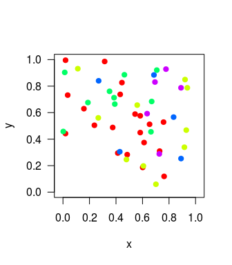

```r
plot(comm1)
```

As mentioned above, abundances and (random) spatial distributions can be also simulated at the same time using `sim_poisson_community`, which essentially calls `sim_sad` and `sim_poisson_coords` consecutively.

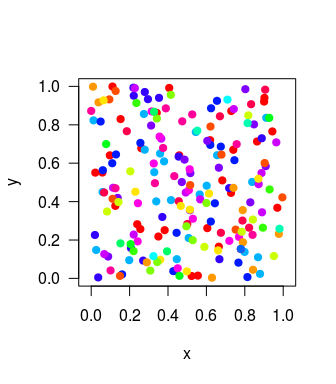

```r
comm2 <- sim_poisson_community(s_pool = 20, n_sim = 200,
                               sad_type = "lnorm",
                               sad_coef = list(cv_abund = 1))
plot(comm2)
```

## 3.2 Aggregated positions

Aggregated, or clustered species distributions are simulated based on the Thomas process, also known as Poisson cluster process, in `mobsim` (Morlon et al. 2008, Wiegand & Moloney 2014). For each species, the Thomas process first distributes a given number of mother points in the landscape. Then, offspring points are distributed around the mother points according to a bivariate Gaussian distance kernel, where the average displacement between mother and offspring points is called `sigma`. The offspring points constitute the final distribution of the species.

By variations in the size of clusters (`sigma`), the number of clusters (`mother_points`), and the mean number of individuals per cluster (`cluster_points`) the Thomas process can generate a large range of different species distributions with intraspecific aggregation.

It is important to note the each species distribution is simulated independently from the other species. That means the Thomas process in `mobsim` cannot be used to simulate spatial dependence between different species, i.e. interspecific aggregation or segregation.

Here is one example for a community with intraspecific aggregation:

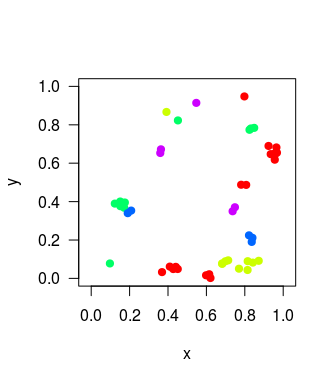

```r
comm3 <- sim_thomas_coords(abund_vec = abund1, sigma = 0.02)
plot(comm3)
```

First, we change the size of the clusters using the argument `sigma`.

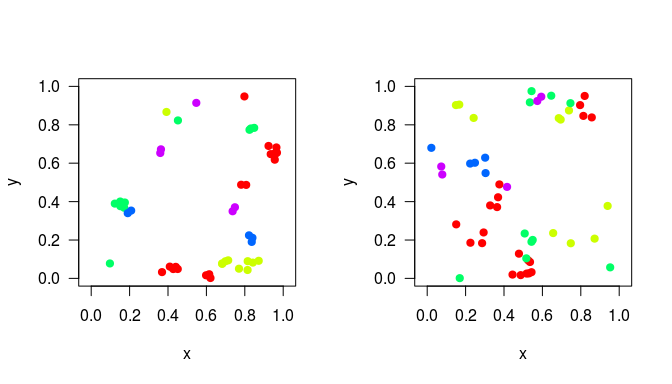

```r
comm3a <- sim_thomas_coords(abund_vec = abund1, sigma = 0.05)
par(mfrow = c(1,2))
plot(comm3)
plot(comm3a)
```

Second, we change the number of clusters per species using the argument `mother_points`.

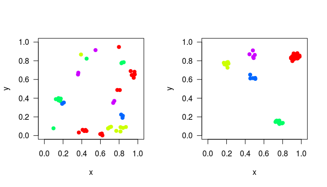

```r
comm3b <- sim_thomas_coords(abund_vec = abund1, sigma = 0.02, mother_points = 1)
par(mfrow = c(1,2))
plot(comm3)
plot(comm3b)
```

Third, we change the average number of points (i.e. individuals) per cluster using the argument `cluster_points`.

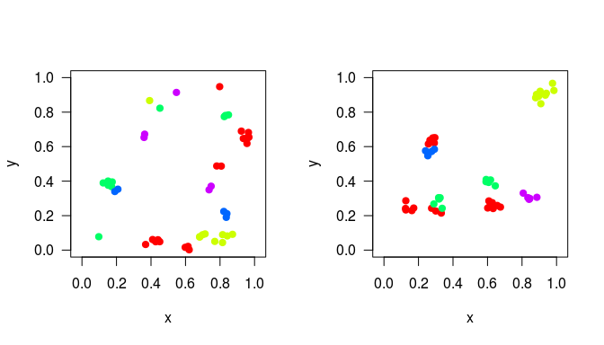

```r
comm3c <- sim_thomas_coords(abund_vec = abund1, sigma = 0.02, cluster_points = 5)
par(mfrow = c(1,2))
plot(comm3)
plot(comm3c)
```

Each of these parameters can be either set to the same equal value for all species as in the examples before, or individually for all species by providing a vector with a length equal to the number of species. For example, each species can has its specific number of clusters.

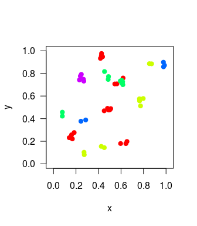

```r
comm4 <- sim_thomas_coords(abund_vec = abund1, sigma = 0.02,
                           mother_points = c(5,4,3,2,1))
plot(comm4)
```

Please note that there can be clusters with zero individuals, so the simulated number of clusters does not necessarily match the parameter settings.

In analogy to random distributions, there is a function to simulate abundances and aggregated distributions at the same time.

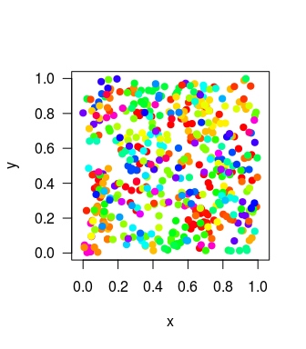

```r
comm5 <- sim_thomas_community(s_pool = 100, n_sim = 500, sad_type = "lnorm",
                              sad_coef = list(cv_abund = 1),sigma = 0.05)
plot(comm5)
```

# 4 References

Morlon et al. 2008. A general framework for the distance-decay of similarity in ecological communities. Ecology Letters 11, 904-917.

Wiegand and Moloney 2014. Handbook of Spatial Point-Pattern Analysis in Ecology. CRC Press